# Parameter Estimate Coverage Assessment

The predictive coverage vignette assesses whether prediction intervals contain observed values. This complementary vignette asks a different question: do the **Wald confidence intervals** for the estimated parameters (sigma, xi, kappa) contain the true parameter values at the nominal rate?

We assess this via Monte Carlo simulation across a grid of true parameter values, using DEGPD model type 1 (the most numerically stable variant).

## Setup

```r
library(egpd)
```

We define a helper function that, for a given set of true parameters, simulates `n_rep` datasets, fits each with `egpd()`, uses `confint()` to obtain Wald 95% CIs on the response scale, and checks whether the true values are covered.

```r
sim_param_coverage <- function(sigma, xi, kappa, n = 500, n_rep = 200,
                               level = 0.95) {
  true_vals <- c(sigma, xi, kappa)

  # Matrices to store results: n_rep x 3
  covered  <- matrix(NA, nrow = n_rep, ncol = 3)
  estimates <- matrix(NA, nrow = n_rep, ncol = 3)
  colnames(covered)  <- c("sigma", "xi", "kappa")
  colnames(estimates) <- c("sigma", "xi", "kappa")

  for (i in seq_len(n_rep)) {
    y <- rdiscegpd(n, sigma = sigma, xi = xi, kappa = kappa, type = 1)
    df <- data.frame(y = y)

    fit <- tryCatch(
      suppressMessages(egpd(list(lsigma = y ~ 1, lxi = ~ 1, lkappa = ~ 1),
           data = df, family = "degpd", degpd.args = list(m = 1))),
      error = function(e) NULL
    )

    if (is.null(fit)) next

    ci <- tryCatch(
      suppressWarnings(confint(fit, method = "wald", level = level)),
      error = function(e) NULL
    )
    if (is.null(ci)) next

    # Response-scale point estimates (level = 0 collapses CI to MLE)
    estimates[i, ] <- confint(fit, method = "wald", level = 0)[, 1]

    for (k in 1:3) {
      if (!any(is.na(ci[k, ])))
        covered[i, k] <- (true_vals[k] >= ci[k, 1]) &
                          (true_vals[k] <= ci[k, 2])
    }
  }

  # Coverage = fraction of successful fits where CI covers truth
  ok <- complete.cases(covered)
  cov_rate <- colMeans(covered[ok, , drop = FALSE])

  # Relative bias = (estimate - true) / true
  ok_est <- complete.cases(estimates)
  rel_bias <- sweep(estimates[ok_est, , drop = FALSE], 2, true_vals, "-")
  rel_bias <- sweep(rel_bias, 2, true_vals, "/")

  list(coverage = cov_rate, n_ok = sum(ok), n_rep = n_rep,
       estimates = estimates[ok_est, , drop = FALSE],
       rel_bias = rel_bias,
       true_vals = true_vals)
}
```

## Varying sigma

We fix xi = 0.2 and kappa = 2, and vary sigma across five values.

```r
set.seed(101)
sigma_vals <- c(1, 2, 3, 5, 10)
xi_fix <- 0.2
kappa_fix <- 2

res_sigma <- lapply(sigma_vals, function(s) {
  sim_param_coverage(sigma = s, xi = xi_fix, kappa = kappa_fix)
})
```

```r
tab_sigma <- do.call(rbind, lapply(seq_along(sigma_vals), function(j) {
  r <- res_sigma[[j]]
  data.frame(sigma_true = sigma_vals[j],
             cov_sigma = round(r$coverage["sigma"], 3),
             cov_xi    = round(r$coverage["xi"], 3),
             cov_kappa = round(r$coverage["kappa"], 3),
             n_ok      = r$n_ok)
}))
tab_sigma
```

```
#>        sigma_true cov_sigma cov_xi cov_kappa n_ok
#> sigma           1     0.905  0.970     0.894  199
#> sigma1          2     0.950  0.970     0.945  199
#> sigma2          3     0.960  0.965     0.945  200
#> sigma3          5     0.965  0.965     0.945  200
#> sigma4         10     0.980  0.945     0.945  200
```

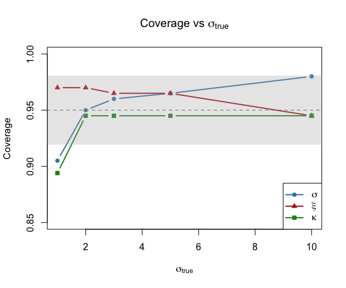

```r
se_cov <- sqrt(0.95 * 0.05 / 200)

plot(sigma_vals, tab_sigma$cov_sigma, type = "b", pch = 16,
     col = "steelblue", lwd = 2, ylim = c(0.85, 1),
     xlab = expression(sigma[true]), ylab = "Coverage",
     main = expression("Coverage vs " * sigma[true]))
lines(sigma_vals, tab_sigma$cov_xi, type = "b", pch = 17,
      col = "firebrick", lwd = 2)
lines(sigma_vals, tab_sigma$cov_kappa, type = "b", pch = 15,
      col = "forestgreen", lwd = 2)
abline(h = 0.95, lty = 2, col = "grey40")
rect(min(sigma_vals) - 1, 0.95 - 2 * se_cov,
     max(sigma_vals) + 1, 0.95 + 2 * se_cov,
     col = adjustcolor("grey70", alpha.f = 0.3), border = NA)
legend("bottomright",
       legend = c(expression(sigma), expression(xi), expression(kappa)),
       col = c("steelblue", "firebrick", "forestgreen"),
       pch = c(16, 17, 15), lwd = 2)
```

## Varying xi

We fix sigma = 3 and kappa = 2, and vary xi.

```r
set.seed(102)
xi_vals <- c(0.05, 0.1, 0.2, 0.5, 1.0)
sigma_fix <- 3

res_xi <- lapply(xi_vals, function(x) {
  sim_param_coverage(sigma = sigma_fix, xi = x, kappa = kappa_fix)
})
```

```r
tab_xi <- do.call(rbind, lapply(seq_along(xi_vals), function(j) {
  r <- res_xi[[j]]
  data.frame(xi_true   = xi_vals[j],
             cov_sigma = round(r$coverage["sigma"], 3),
             cov_xi    = round(r$coverage["xi"], 3),
             cov_kappa = round(r$coverage["kappa"], 3),
             n_ok      = r$n_ok)
}))
tab_xi
```

```
#>        xi_true cov_sigma cov_xi cov_kappa n_ok
#> sigma     0.05     0.905   0.91     0.940  200
#> sigma1    0.10     0.915   0.94     0.930  200
#> sigma2    0.20     0.945   0.95     0.950  200
#> sigma3    0.50     0.955   0.95     0.970  200
#> sigma4    1.00     0.965   0.95     0.975  199
```

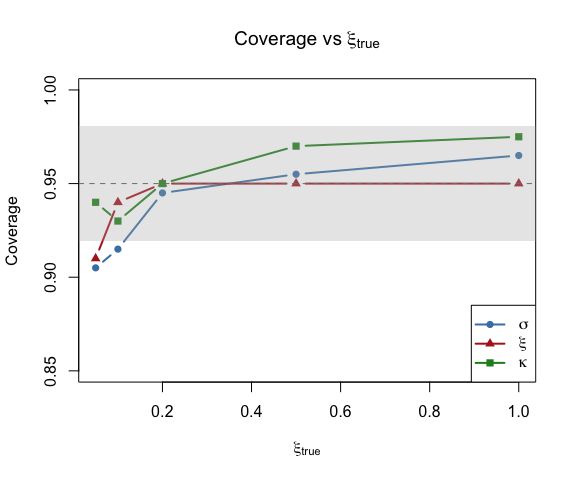

```r
plot(xi_vals, tab_xi$cov_sigma, type = "b", pch = 16,
     col = "steelblue", lwd = 2, ylim = c(0.85, 1),
     xlab = expression(xi[true]), ylab = "Coverage",
     main = expression("Coverage vs " * xi[true]))
lines(xi_vals, tab_xi$cov_xi, type = "b", pch = 17,
      col = "firebrick", lwd = 2)
lines(xi_vals, tab_xi$cov_kappa, type = "b", pch = 15,
      col = "forestgreen", lwd = 2)
abline(h = 0.95, lty = 2, col = "grey40")
rect(min(xi_vals) - 0.1, 0.95 - 2 * se_cov,
     max(xi_vals) + 0.1, 0.95 + 2 * se_cov,
     col = adjustcolor("grey70", alpha.f = 0.3), border = NA)
legend("bottomright",
       legend = c(expression(sigma), expression(xi), expression(kappa)),
       col = c("steelblue", "firebrick", "forestgreen"),
       pch = c(16, 17, 15), lwd = 2)
```

## Varying kappa

We fix sigma = 3 and xi = 0.2, and vary kappa.

```r
set.seed(103)
kappa_vals <- c(0.5, 1, 2, 3, 5)
xi_fix2 <- 0.2

res_kappa <- lapply(kappa_vals, function(k) {
  sim_param_coverage(sigma = sigma_fix, xi = xi_fix2, kappa = k)
})
```

```r
tab_kappa <- do.call(rbind, lapply(seq_along(kappa_vals), function(j) {
  r <- res_kappa[[j]]
  data.frame(kappa_true = kappa_vals[j],
             cov_sigma  = round(r$coverage["sigma"], 3),
             cov_xi     = round(r$coverage["xi"], 3),
             cov_kappa  = round(r$coverage["kappa"], 3),
             n_ok       = r$n_ok)
}))
tab_kappa
```

```
#>        kappa_true cov_sigma cov_xi cov_kappa n_ok
#> sigma         0.5     0.905  0.950      0.93  200
#> sigma1        1.0     0.955  0.970      0.96  200
#> sigma2        2.0     0.945  0.955      0.94  200
#> sigma3        3.0     0.950  0.975      0.96  199
#> sigma4        5.0     0.960  0.970      0.96  200
```

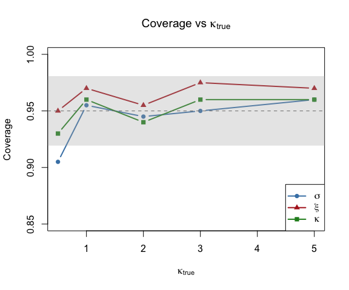

```r
plot(kappa_vals, tab_kappa$cov_sigma, type = "b", pch = 16,
     col = "steelblue", lwd = 2, ylim = c(0.85, 1),
     xlab = expression(kappa[true]), ylab = "Coverage",
     main = expression("Coverage vs " * kappa[true]))
lines(kappa_vals, tab_kappa$cov_xi, type = "b", pch = 17,
      col = "firebrick", lwd = 2)
lines(kappa_vals, tab_kappa$cov_kappa, type = "b", pch = 15,
      col = "forestgreen", lwd = 2)
abline(h = 0.95, lty = 2, col = "grey40")
rect(min(kappa_vals) - 0.5, 0.95 - 2 * se_cov,
     max(kappa_vals) + 0.5, 0.95 + 2 * se_cov,
     col = adjustcolor("grey70", alpha.f = 0.3), border = NA)
legend("bottomright",
       legend = c(expression(sigma), expression(xi), expression(kappa)),
       col = c("steelblue", "firebrick", "forestgreen"),
       pch = c(16, 17, 15), lwd = 2)
```

## Bias and precision

Beyond coverage, it is useful to check whether the estimator is approximately unbiased. The boxplots below show the relative bias (estimate - true) / true for each parameter across all 15 scenarios.

```r
# Combine all relative bias matrices with scenario labels
make_bias_df <- function(res_list, varied_name, varied_vals, fixed_label) {
  do.call(rbind, lapply(seq_along(varied_vals), function(j) {
    rb <- as.data.frame(res_list[[j]]$rel_bias)
    rb$scenario <- paste0(varied_name, " = ", varied_vals[j])
    rb$group <- fixed_label
    rb
  }))
}

bias_sigma <- make_bias_df(res_sigma, "sigma", sigma_vals, "Vary sigma")
bias_xi    <- make_bias_df(res_xi, "xi", xi_vals, "Vary xi")
bias_kappa <- make_bias_df(res_kappa, "kappa", kappa_vals, "Vary kappa")
bias_all   <- rbind(bias_sigma, bias_xi, bias_kappa)
```

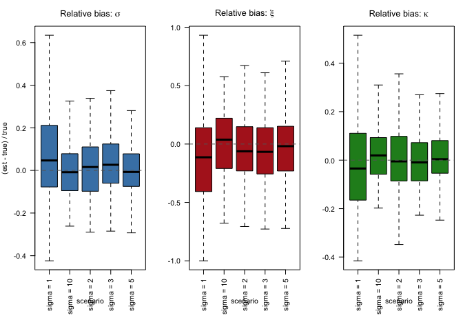

```r
par(mfrow = c(1, 3), mar = c(7, 4, 3, 1))

boxplot(sigma ~ scenario, data = bias_sigma,
        main = expression("Relative bias: " * sigma),
        ylab = "(est - true) / true", las = 2, col = "steelblue",
        outline = FALSE)
abline(h = 0, lty = 2, col = "grey40")

boxplot(xi ~ scenario, data = bias_sigma,
        main = expression("Relative bias: " * xi),
        ylab = "", las = 2, col = "firebrick",
        outline = FALSE)
abline(h = 0, lty = 2, col = "grey40")

boxplot(kappa ~ scenario, data = bias_sigma,
        main = expression("Relative bias: " * kappa),
        ylab = "", las = 2, col = "forestgreen",
        outline = FALSE)
abline(h = 0, lty = 2, col = "grey40")
```

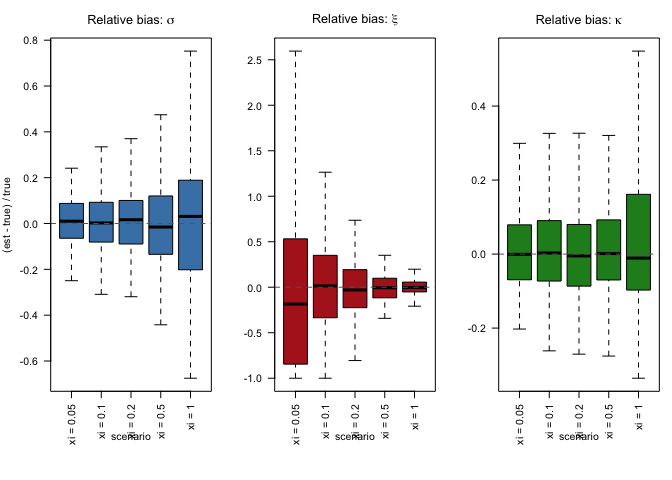

```r
par(mfrow = c(1, 3), mar = c(7, 4, 3, 1))

boxplot(sigma ~ scenario, data = bias_xi,
        main = expression("Relative bias: " * sigma),
        ylab = "(est - true) / true", las = 2, col = "steelblue",
        outline = FALSE)
abline(h = 0, lty = 2, col = "grey40")

boxplot(xi ~ scenario, data = bias_xi,
        main = expression("Relative bias: " * xi),
        ylab = "", las = 2, col = "firebrick",
        outline = FALSE)
abline(h = 0, lty = 2, col = "grey40")

boxplot(kappa ~ scenario, data = bias_xi,
        main = expression("Relative bias: " * kappa),
        ylab = "", las = 2, col = "forestgreen",
        outline = FALSE)
abline(h = 0, lty = 2, col = "grey40")
```

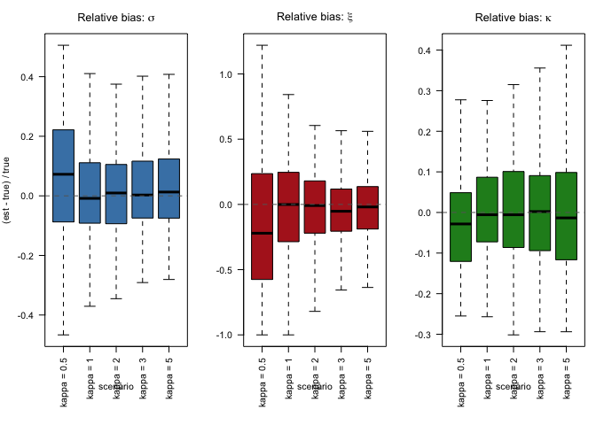

```r
par(mfrow = c(1, 3), mar = c(7, 4, 3, 1))

boxplot(sigma ~ scenario, data = bias_kappa,
        main = expression("Relative bias: " * sigma),
        ylab = "(est - true) / true", las = 2, col = "steelblue",
        outline = FALSE)
abline(h = 0, lty = 2, col = "grey40")

boxplot(xi ~ scenario, data = bias_kappa,
        main = expression("Relative bias: " * xi),
        ylab = "", las = 2, col = "firebrick",
        outline = FALSE)
abline(h = 0, lty = 2, col = "grey40")

boxplot(kappa ~ scenario, data = bias_kappa,
        main = expression("Relative bias: " * kappa),
        ylab = "", las = 2, col = "forestgreen",
        outline = FALSE)
abline(h = 0, lty = 2, col = "grey40")
```